# Úloha predikce poskytnutí úvěru bankovním klientům

Cílem práce je sestavení různých modelů metod ML pro účely predikce poskytnutí bankovního úvěru klientům.

Pro tento účel je použit dataset obsahující údaje o bankovních klientech ve vztahu ke skutečnosti, zda jim byl poskytnut úvěr či nikoli. Data pocházejí z https://www.kaggle.com/sriharipramod/bank-loan-classification.

## Načtení a prvotní seznámení s daty

V rámci této fáze projektu dochází k načtení výchozích dat a prvotnímu seznámení s daty.

Import základních balíčků:

```r
library(readr)
library(dplyr)
library(ggplot2)
library(dlookr)
library(tidyr)
library(reshape2)
library(gridExtra)
library(fastDummies)
library(tidyverse)
library(cowplot)
```

Načtení výchozích dat:

```r
universalbank_df <- read.csv('UniversalBank.csv', na = c('', 'NA', '?'), header = TRUE, encoding = 'UTF-8')
class(universalbank_df)
```

```
## [1] "data.frame"
```

### Základní porozumění datasetu

Dimenze vstupní matice dat:

```r
dim(universalbank_df)
```

```
## [1] 5000   14
```

Datové typy atributů:

```r
str(universalbank_df)
```

```
## 'data.frame':    5000 obs. of  14 variables:
##  $ ID                : int  1 2 3 4 5 6 7 8 9 10 ...
##  $ Age               : int  25 45 39 35 35 37 53 50 35 34 ...
##  $ Experience        : int  1 19 15 9 8 13 27 24 10 9 ...
##  $ Income            : int  49 34 11 100 45 29 72 22 81 180 ...
##  $ ZIP.Code          : int  91107 90089 94720 94112 91330 92121 91711 93943 90089 93023 ...
##  $ Family            : int  4 3 1 1 4 4 2 1 3 1 ...
##  $ CCAvg             : num  1.6 1.5 1 2.7 1 0.4 1.5 0.3 0.6 8.9 ...
##  $ Education         : int  1 1 1 2 2 2 2 3 2 3 ...
##  $ Mortgage          : int  0 0 0 0 0 155 0 0 104 0 ...
##  $ Personal.Loan     : int  0 0 0 0 0 0 0 0 0 1 ...
##  $ Securities.Account: int  1 1 0 0 0 0 0 0 0 0 ...
##  $ CD.Account        : int  0 0 0 0 0 0 0 0 0 0 ...
##  $ Online            : int  0 0 0 0 0 1 1 0 1 0 ...
##  $ CreditCard        : int  0 0 0 0 1 0 0 1 0 0 ...
```

Zobrazení prvních 5 řádků:

```r
head(universalbank_df)
```

```
##   ID Age Experience Income ZIP.Code Family CCAvg Education Mortgage
## 1  1  25          1     49    91107      4   1.6         1        0
## 2  2  45         19     34    90089      3   1.5         1        0
## 3  3  39         15     11    94720      1   1.0         1        0
## 4  4  35          9    100    94112      1   2.7         2        0
## 5  5  35          8     45    91330      4   1.0         2        0
## 6  6  37         13     29    92121      4   0.4         2      155
##   Personal.Loan Securities.Account CD.Account Online CreditCard
## 1             0                  1          0      0          0
## 2             0                  1          0      0          0
## 3             0                  0          0      0          0
## 4             0                  0          0      0          0
## 5             0                  0          0      0          1
## 6             0                  0          0      1          0
```

Zobrazení posledních 5 řádků:

```r
tail(universalbank_df)
```

```
##        ID Age Experience Income ZIP.Code Family CCAvg Education Mortgage
## 4995 4995  64         40     75    94588      3   2.0         3        0
## 4996 4996  29          3     40    92697      1   1.9         3        0
## 4997 4997  30          4     15    92037      4   0.4         1       85
## 4998 4998  63         39     24    93023      2   0.3         3        0
## 4999 4999  65         40     49    90034      3   0.5         2        0
## 5000 5000  28          4     83    92612      3   0.8         1        0
##      Personal.Loan Securities.Account CD.Account Online CreditCard
## 4995             0                  0          0      1          0
## 4996             0                  0          0      1          0
## 4997             0                  0          0      1          0
## 4998             0                  0          0      0          0
## 4999             0                  0          0      1          0
## 5000             0                  0          0      1          1
```

Názvy atributů:

```r
colnames(universalbank_df)
```

```
##  [1] "ID"                 "Age"                "Experience"
##  [4] "Income"             "ZIP.Code"           "Family"
##  [7] "CCAvg"              "Education"          "Mortgage"
## [10] "Personal.Loan"      "Securities.Account" "CD.Account"
## [13] "Online"             "CreditCard"
```

Základní statistické charakteristiky atributů:

```r
summary(universalbank_df)
```

```
##        ID            Age          Experience       Income          ZIP.Code
##  Min.   :   1   Min.   :23.00   Min.   :-3.0   Min.   :  8.00   Min.   : 9307
##  1st Qu.:1251   1st Qu.:35.00   1st Qu.:10.0   1st Qu.: 39.00   1st Qu.:91911
##  Median :2500   Median :45.00   Median :20.0   Median : 64.00   Median :93437
##  Mean   :2500   Mean   :45.34   Mean   :20.1   Mean   : 73.77   Mean   :93153
##  3rd Qu.:3750   3rd Qu.:55.00   3rd Qu.:30.0   3rd Qu.: 98.00   3rd Qu.:94608
##  Max.   :5000   Max.   :67.00   Max.   :43.0   Max.   :224.00   Max.   :96651
##      Family          CCAvg          Education        Mortgage
##  Min.   :1.000   Min.   : 0.000   Min.   :1.000   Min.   :  0.0
##  1st Qu.:1.000   1st Qu.: 0.700   1st Qu.:1.000   1st Qu.:  0.0
##  Median :2.000   Median : 1.500   Median :2.000   Median :  0.0
##  Mean   :2.396   Mean   : 1.938   Mean   :1.881   Mean   : 56.5
##  3rd Qu.:3.000   3rd Qu.: 2.500   3rd Qu.:3.000   3rd Qu.:101.0
##  Max.   :4.000   Max.   :10.000   Max.   :3.000   Max.   :635.0
##  Personal.Loan   Securities.Account   CD.Account         Online
##  Min.   :0.000   Min.   :0.0000     Min.   :0.0000   Min.   :0.0000
##  1st Qu.:0.000   1st Qu.:0.0000     1st Qu.:0.0000   1st Qu.:0.0000
##  Median :0.000   Median :0.0000     Median :0.0000   Median :1.0000
##  Mean   :0.096   Mean   :0.1044     Mean   :0.0604   Mean   :0.5968
##  3rd Qu.:0.000   3rd Qu.:0.0000     3rd Qu.:0.0000   3rd Qu.:1.0000
##  Max.   :1.000   Max.   :1.0000     Max.   :1.0000   Max.   :1.0000
##    CreditCard
##  Min.   :0.000
##  1st Qu.:0.000
##  Median :0.000
##  Mean   :0.294
##  3rd Qu.:1.000
##  Max.   :1.000
```

Počet chybějících hodnot v datasetu:

```r
sum(is.na(universalbank_df))
```

```
## [1] 0
```

Počet chybějících hodnot podle atributů:

```r
sapply(universalbank_df, function(x) sum(is.na(x)))
```

```
##                 ID                Age         Experience             Income
##                  0                  0                  0                  0
##           ZIP.Code             Family              CCAvg          Education
##                  0                  0                  0                  0
##           Mortgage      Personal.Loan Securities.Account         CD.Account
##                  0                  0                  0                  0
##             Online         CreditCard
##                  0                  0
```

## Vizualizace a předzpracování

Nyní dochází k vizualizaci dat a k jejich předzpracování. Vzhledem k povaze dat nebylo možné provést všechny požadavky na předzpracování.

Místo vytváření subsetu odstraněním řádků, které by vedlo ke zbytečné ztrátě informací a ke zkreslení reprezentativnosti datasetu, jsme raději přistoupili k odstraňování nevýznamných sloupců.

Vytváření nových atributů dochází pomocí dichotomizace kategoriálních proměnných.

Z povahy dat, kdy jeden záznam reprezentuje právě jednoho klienta, jsme nepřistoupili k aplikaci agregačních operátorů.

Vzhledem k absenci chybějících hodnot není možné chybějící hodnoty jakýmkoli způsobem ošetřovat, nicméně jsou použity mechanismy pro jejich detekci.

Změna datového typu u proměnných, které jsou kateroriální povahy, z *int* na *factor*.

```r
universalbank_df <- universalbank_df %>%
  mutate(Personal.Loan = as.factor(Personal.Loan),
         Securities.Account = as.factor(Securities.Account),
         CD.Account = as.factor(CD.Account),
         Online = as.factor(Online),
         CreditCard = as.factor(CreditCard),
         Family = as.factor(Family),
         Education = as.factor(Education))

str(universalbank_df)
```

```
## 'data.frame':    5000 obs. of  14 variables:
##  $ ID                : int  1 2 3 4 5 6 7 8 9 10 ...
##  $ Age               : int  25 45 39 35 35 37 53 50 35 34 ...
##  $ Experience        : int  1 19 15 9 8 13 27 24 10 9 ...
##  $ Income            : int  49 34 11 100 45 29 72 22 81 180 ...
##  $ ZIP.Code          : int  91107 90089 94720 94112 91330 92121 91711 93943 90089 93023 ...
##  $ Family            : Factor w/ 4 levels "1","2","3","4": 4 3 1 1 4 4 2 1 3 1 ...
##  $ CCAvg             : num  1.6 1.5 1 2.7 1 0.4 1.5 0.3 0.6 8.9 ...
##  $ Education         : Factor w/ 3 levels "1","2","3": 1 1 1 2 2 2 2 3 2 3 ...
##  $ Mortgage          : int  0 0 0 0 0 155 0 0 104 0 ...
##  $ Personal.Loan     : Factor w/ 2 levels "0","1": 1 1 1 1 1 1 1 1 1 2 ...
##  $ Securities.Account: Factor w/ 2 levels "0","1": 2 2 1 1 1 1 1 1 1 1 ...
##  $ CD.Account        : Factor w/ 2 levels "0","1": 1 1 1 1 1 1 1 1 1 1 ...
##  $ Online            : Factor w/ 2 levels "0","1": 1 1 1 1 1 2 2 1 2 1 ...
##  $ CreditCard        : Factor w/ 2 levels "0","1": 1 1 1 1 2 1 1 2 1 1 ...
```

Odstranění z hlediska úlohy bezvýznamných atributů *ZIP.Code* a *ID*:

```r
universalbank_df <- universalbank_df %>%
  select(Age, Experience, Income, Family, CCAvg, Education, Mortgage,
         Personal.Loan, Securities.Account, CD.Account, Online, CreditCard)
```

Histogramy jednotlivých atributů podmíněné cílovým atributem *Personal.Loan*:

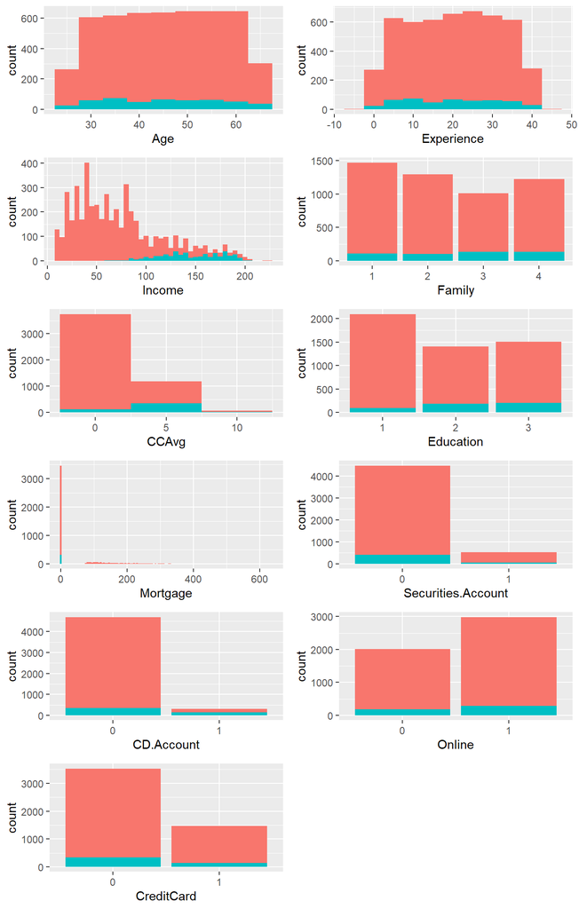

```r
g1 <- ggplot(universalbank_df, aes(x = Age, fill = Personal.Loan)) + geom_histogram(binwidth=5)+ theme(legend.position="none")
g2 <- ggplot(universalbank_df, aes(x = Experience, fill = Personal.Loan)) + geom_histogram(binwidth = 5)+ theme(legend.position="none")
g3 <- ggplot(universalbank_df, aes(x = Income, fill = Personal.Loan)) + geom_histogram(binwidth = 5)+ theme(legend.position="none")
g4 <- ggplot(universalbank_df, aes(x = Family, fill = Personal.Loan)) + geom_histogram(stat="count")+ theme(legend.position="none")
g5 <- ggplot(universalbank_df, aes(x = CCAvg, fill = Personal.Loan)) + geom_histogram(binwidth = 5)+ theme(legend.position="none")
g6 <- ggplot(universalbank_df, aes(x = Education , fill = Personal.Loan)) + geom_histogram(stat="count")+ theme(legend.position="none")
g7 <- ggplot(universalbank_df, aes(x = Mortgage, fill = Personal.Loan)) + geom_histogram(binwidth = 5)+ theme(legend.position="none")
g8 <- ggplot(universalbank_df, aes(x = Securities.Account, fill = Personal.Loan)) + geom_histogram(stat="count")+ theme(legend.position="none")
g9 <- ggplot(universalbank_df, aes(x = CD.Account, fill = Personal.Loan)) + geom_histogram(stat="count")+ theme(legend.position="none")
g10 <- ggplot(universalbank_df, aes(x = Online, fill = Personal.Loan)) + geom_histogram(stat="count")+ theme(legend.position="none")
g11 <- ggplot(universalbank_df, aes(x = CreditCard, fill = Personal.Loan)) + geom_histogram(stat="count")+ theme(legend.position="none")

grid.arrange(g1, g2, g3, g4, g5, g6, g7, g8, g9, g10, g11, nrow = 6, ncol=2, widths = c(2,2))
```

Histogram cílového atributu *Personal.Loan*:

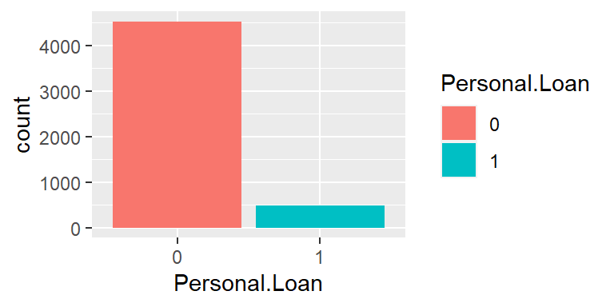

```r
ggplot(data = universalbank_df, aes(x = Personal.Loan, fill = Personal.Loan)) + geom_bar()
```

Počet záznamů v datasetu s hodnotou cílového atributu rovno 1, resp. Ano:

```r
sum(universalbank_df$Personal.Loan == 1)
```

```
## [1] 480
```

Počet záznamů v datasetu s hodnotou cílového atributu rovno 0, resp. Ne:

```r
sum(universalbank_df$Personal.Loan == 0)
```

```
## [1] 4520
```

Z výše uvedených výstupů je patrné, že dataset je z hlediska cílového atributu nevyrovnaný.

Korelační matice spojitých numerických atributů:

```r
data <- as.matrix(select_if(universalbank_df, is.numeric))

res <- cor(data)
round(res, 2)
```

```
##              Age Experience Income CCAvg Mortgage
## Age         1.00       0.99  -0.06 -0.05    -0.01
## Experience  0.99       1.00  -0.05 -0.05    -0.01
## Income     -0.06      -0.05   1.00  0.65     0.21
## CCAvg      -0.05      -0.05   0.65  1.00     0.11
## Mortgage   -0.01      -0.01   0.21  0.11     1.00
```

Grafická reprezentace korelační matice:

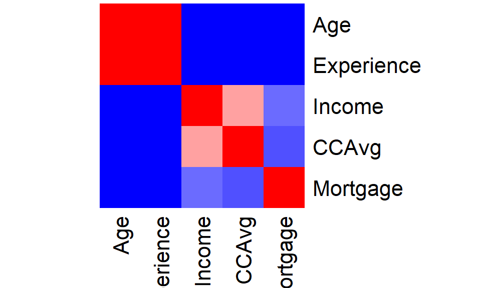

```r
col<- colorRampPalette(c("blue", "white", "red"))(20)
heatmap(x = res, col = col, symm = TRUE, Rowv = NA)
```

Je patrné, že mezi atributy *Experience* a *Age* je téměř perfektní korelace. Data jsou tedy zatížena perfektní multikolinearitou, kterou odstraníme tím, že jednu z těchto proměnných vynecháme. Jmenovitě vynecháme proměnnou *Experience*.

V případě neošetření perfektní multikolinearity v datech by byly negativně ovlivněny modely ve fázi trénování.

Vynechání atributu *Experience*:

```r
universalbank_df <- subset(universalbank_df, select = -c(Experience))
```

Dichotomizace kategoriálních atributů o více než dvou hodnotách a jejich transformace na datový typ *factor*:

```r
universalbank_df <- dummy_cols(universalbank_df, select_columns = c('Family', 'Education'),
                               remove_first_dummy = T,
                               remove_selected_columns = T)

universalbank_df <- universalbank_df %>%
  mutate(Family_2 = as.factor(Family_2),
         Family_3 = as.factor(Family_3),
         Family_4 = as.factor(Family_4),
         Education_2 = as.factor(Education_2),
         Education_3 = as.factor(Education_3))

str(universalbank_df)
```

```
## 'data.frame':    5000 obs. of  14 variables:
##  $ Age               : int  25 45 39 35 35 37 53 50 35 34 ...
##  $ Income            : int  49 34 11 100 45 29 72 22 81 180 ...
##  $ CCAvg             : num  1.6 1.5 1 2.7 1 0.4 1.5 0.3 0.6 8.9 ...
##  $ Mortgage          : int  0 0 0 0 0 155 0 0 104 0 ...
##  $ Personal.Loan     : Factor w/ 2 levels "0","1": 1 1 1 1 1 1 1 1 1 2 ...
##  $ Securities.Account: Factor w/ 2 levels "0","1": 2 2 1 1 1 1 1 1 1 1 ...
##  $ CD.Account        : Factor w/ 2 levels "0","1": 1 1 1 1 1 1 1 1 1 1 ...
##  $ Online            : Factor w/ 2 levels "0","1": 1 1 1 1 1 2 2 1 2 1 ...
##  $ CreditCard        : Factor w/ 2 levels "0","1": 1 1 1 1 2 1 1 2 1 1 ...
##  $ Family_2          : Factor w/ 2 levels "0","1": 1 1 1 1 1 1 2 1 1 1 ...
##  $ Family_3          : Factor w/ 2 levels "0","1": 1 2 1 1 1 1 1 1 2 1 ...
##  $ Family_4          : Factor w/ 2 levels "0","1": 2 1 1 1 2 2 1 1 1 1 ...
##  $ Education_2       : Factor w/ 2 levels "0","1": 1 1 1 2 2 2 2 1 2 1 ...
##  $ Education_3       : Factor w/ 2 levels "0","1": 1 1 1 1 1 1 1 2 1 2 ...
```

Dataset je připraven pro modelování.

## Modelování

V této části dochází k vytvoření modelů následujících metod strojového učení:

- Logistická regrese,
- Random Forest.

V rámci každé metody je vytvořen model, který je je optimalizován z hlediska hodnot vybraných hyperparametrů.

Načtění potrebných balíčků ve fázi modelování:

```r
library(caret)
library(stepPlr)
library(randomForest)
library(MLeval)
```

Nastavení *seed* pro reprodukovatenost a překódování hodnot cílového atributu:

```r
universalbank_df <- universalbank_df %>%
  mutate(Personal.Loan = dplyr::recode(Personal.Loan, '1' = "Yes", '0' = "No"))

str(universalbank_df)
```

```
## 'data.frame':    5000 obs. of  14 variables:
##  $ Age               : int  25 45 39 35 35 37 53 50 35 34 ...
##  $ Income            : int  49 34 11 100 45 29 72 22 81 180 ...
##  $ CCAvg             : num  1.6 1.5 1 2.7 1 0.4 1.5 0.3 0.6 8.9 ...
##  $ Mortgage          : int  0 0 0 0 0 155 0 0 104 0 ...
##  $ Personal.Loan     : Factor w/ 2 levels "No","Yes": 1 1 1 1 1 1 1 1 1 2 ...
##  $ Securities.Account: Factor w/ 2 levels "0","1": 2 2 1 1 1 1 1 1 1 1 ...
##  $ CD.Account        : Factor w/ 2 levels "0","1": 1 1 1 1 1 1 1 1 1 1 ...
##  $ Online            : Factor w/ 2 levels "0","1": 1 1 1 1 1 2 2 1 2 1 ...
##  $ CreditCard        : Factor w/ 2 levels "0","1": 1 1 1 1 2 1 1 2 1 1 ...
##  $ Family_2          : Factor w/ 2 levels "0","1": 1 1 1 1 1 1 2 1 1 1 ...
##  $ Family_3          : Factor w/ 2 levels "0","1": 1 2 1 1 1 1 1 1 2 1 ...
##  $ Family_4          : Factor w/ 2 levels "0","1": 2 1 1 1 2 2 1 1 1 1 ...
##  $ Education_2       : Factor w/ 2 levels "0","1": 1 1 1 2 2 2 2 1 2 1 ...
##  $ Education_3       : Factor w/ 2 levels "0","1": 1 1 1 1 1 1 1 2 1 2 ...
```

Rozdělení datasetu na trénovací a testovací část v poměru 80:20. Při dělení datasetu dochází k zachování stejného podílu hodnot cílového atributu v obou částech datasetu:

```r
set.seed(123)
index_train <-
  createDataPartition(universalbank_df$Personal.Loan,
                      p = .8,
                      list = FALSE)
train <- universalbank_df[index_train, ]
test  <- universalbank_df[-index_train, ]

sum(train$Personal.Loan == 'Yes')
```

```
## [1] 384
```

```r
sum(train$Personal.Loan == 'No')
```

```
## [1] 3616
```

```r
sum(test$Personal.Loan == 'Yes')
```

```
## [1] 96
```

```r
sum(test$Personal.Loan == 'No')
```

```
## [1] 904
```

### Logistická regrese

V prvé řadě dochází k definování kontrolní funkce, která stanovuje parametry procesu učení modelu metody LR. V rámci trénování modelu metody LR je použita 10 násobná křížová validace. Optimální nastavení hyperparamerů je hledáno pomocí *grid search*:

```r
fitControl <- trainControl(
  method = "cv",
  number = 10,
  summaryFunction = twoClassSummary,
  classProbs = T,
  savePredictions = T,
  search = 'grid'
)
```

Definování prostoru laděných hyperparametrů metody LR v rámci křížové validace:

```r
plr_grid <- expand.grid(cp = c('aic', 'bic'),
                        lambda = c(0.0001, 0.001, 0.01, 0.1, 1, 10, 100))
```

Funkce řídící proces učení. Agreguje v sobě:

- data, na kterých probíhá proces učení,
- použitou metodu ML (Penalized Logistic Regression),
- parametry procesu učení (10x cross validace, grid search),
- kroky predzpracovnání dat (centrování, normalizace),
- prostor laděných hyperparametrů použité metody ML (cp, lambda),
- evaluační metrika (ROC).

```r
set.seed(123)

plr_fit <- train(
  Personal.Loan ~ .,
  data = train,
  method = "plr",
  trControl = fitControl,
  preProc = c("center", "scale"),
  tuneGrid = plr_grid,
  metric = "ROC"
)

plr_fit
```

```
## Penalized Logistic Regression
##
## 4000 samples
##   13 predictor
##    2 classes: 'No', 'Yes'
##
## Pre-processing: centered (13), scaled (13)
## Resampling: Cross-Validated (10 fold)
## Summary of sample sizes: 3600, 3600, 3601, 3601, 3599, 3600, ...
## Resampling results across tuning parameters:
##
##   cp   lambda  ROC        Sens       Spec
##   aic  1e-04   0.9627812  0.9897660  0.6846829
##   aic  1e-03   0.9627812  0.9897660  0.6846829
##   aic  1e-02   0.9627957  0.9897660  0.6846829
##   aic  1e-01   0.9627896  0.9897660  0.6846829
##   aic  1e+00   0.9633746  0.9903185  0.6717274
##   aic  1e+01   0.9645857  0.9933625  0.5935897
##   aic  1e+02   0.9585640  0.9975115  0.3336032
##   bic  1e-04   0.9627812  0.9897660  0.6846829
##   bic  1e-03   0.9627812  0.9897660  0.6846829
##   bic  1e-02   0.9627957  0.9897660  0.6846829
##   bic  1e-01   0.9627896  0.9897660  0.6846829
##   bic  1e+00   0.9633746  0.9903185  0.6717274
##   bic  1e+01   0.9645857  0.9933625  0.5935897
##   bic  1e+02   0.9585640  0.9975115  0.3336032
##
## ROC was used to select the optimal model using the largest value.
## The final values used for the model were lambda = 10 and cp = aic.
```

Následuje vizualizace výsledků křížové validace na trénovacích datech. Graf zobrazuje hodnotu evalační metriky pro jednotlivá nastavení hyperparametrů modelu metody LR v rámci křížové validace:

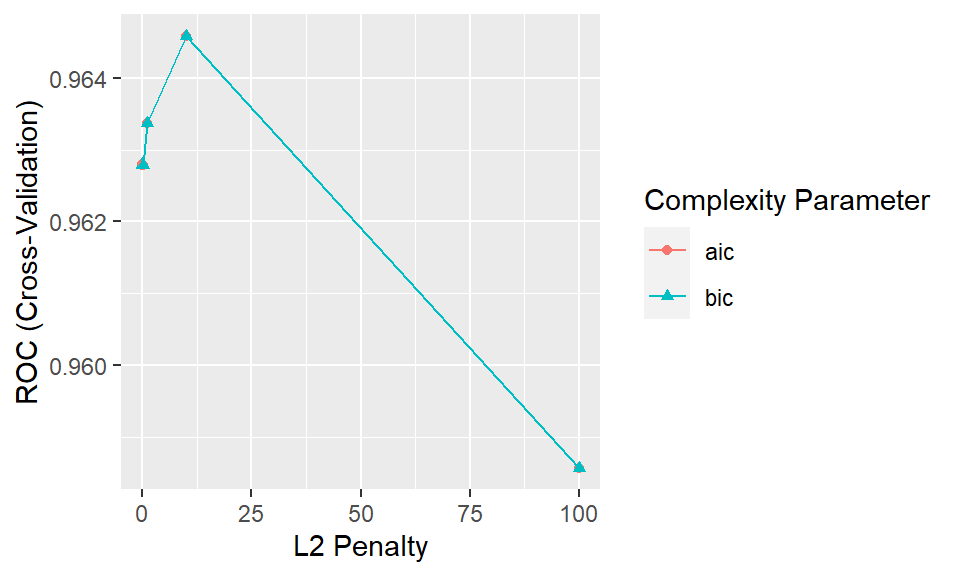

```r
ggplot(plr_fit)
```

Na základě, jak výpisu výsledků křížové validace, tak následné vizualizace, lze konstatovat, že model metody LR s *lambda = 10* a *cp = aic* dosahuje v rámci křízové validace na testovací části trénovacích dat nejlepších predikčních schopností. Hodnota evaluační metriky *ROC* dosahuje u modelu s tímto nastavením hyperparametrů nejvyšší hodnoty. Tento model LR lze považovat za optimální v hyperparametech.

Nyní se v hyperparametrech optimální model LR použije pro predikci na testovacím datasetu.

```r
plr_predicted_class <- predict(plr_fit, newdata = test)
str(plr_predicted_class)
```

```
##  Factor w/ 2 levels "No","Yes": 1 1 1 1 1 1 1 1 1 1 ...
```

Natrénovaný model LR umožňuje predikovat pravděpodobnost příslušnosti testovacích záznamů k jednotlivým třídám cílového atributu:

```r
plr_predicted_proba <- predict(plr_fit, newdata = test, type = "prob")
head(plr_predicted_proba)
```

```
##          No         Yes
## 1 0.9914672 0.008532842
## 2 0.9982414 0.001758575
## 3 0.9802866 0.019713434
## 4 0.9987902 0.001209786
## 5 0.8722638 0.127736202
## 6 0.9968957 0.003104332
```

Za účelem zhodnocení predikčních schopností modelu LR na testovacích datech si necháme zobrazit *matici záměn* včetně dopočítaných evaluačních metrik.

```r
confusionMatrix(data = plr_predicted_class, test$Personal.Loan)
```

```
## Confusion Matrix and Statistics
##
##           Reference
## Prediction  No Yes
##        No  892  39
##        Yes  12  57
##
##                Accuracy : 0.949
##                  95% CI : (0.9335, 0.9618)
##     No Information Rate : 0.904
##     P-Value [Acc > NIR] : 1.104e-07
##
##                   Kappa : 0.6639
##
##  Mcnemar's Test P-Value : 0.0002719
##
##             Sensitivity : 0.9867
##             Specificity : 0.5938
##          Pos Pred Value : 0.9581
##          Neg Pred Value : 0.8261
##              Prevalence : 0.9040
##          Detection Rate : 0.8920
##    Detection Prevalence : 0.9310
##       Balanced Accuracy : 0.7902
##
##        'Positive' Class : No
##
```

Výše uvedeného výpisu lze mimo jiné vyčíst celkovou správnost klasifikace. Celková správnost klasifikace na testovacích datech dosahuje hodnoty 0.949. Model správně klasifikoval 95 % testovacích dat.

Kromě klasického vyhodnocení pomocí výše uvedených metrik je možné použít i evaluaci založenou na komplexnějších metrikách reprezentovaných křivkou. Jmenovitě jsou použity následující komplexnější metriky:

- ROC křivka,
- křivka kumulativních zisků.

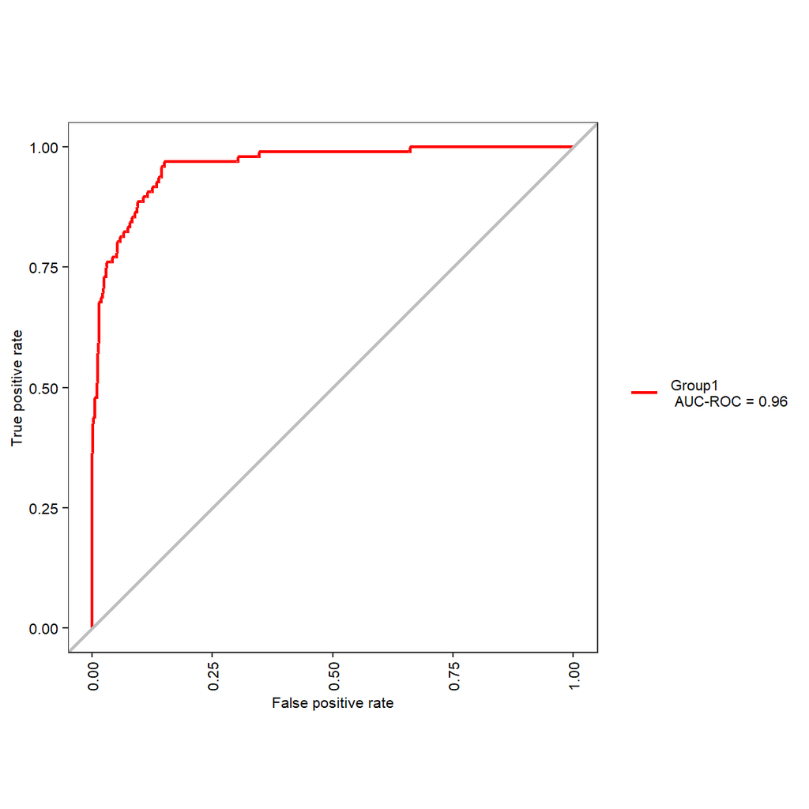

```r
plr_predicted_proba$obs <- test$Personal.Loan

roc_curve_lr <- evalm(plr_predicted_proba ,plots='r',rlinethick=0.8,fsize=8,bins=8)
```

ROC křivka dává v souvislost TP poměr a FP poměr. Čím je se průběh křivky blíží levému hornímu rohu, tím je vyšší poměr TP (podíl správně klasifikovaných pozitivních případů na všech pozitivních případech) vázán s nižším FP poměrem (podíl špatně klasifikovaných negativních případů na všech negativních případech).

Křivka kumulativních zisků dává v souvislost procento případů s modelem predikovanou nejvyšší pravděpodobností a procento všech případů dané třídy. Za učelem její kontrukce je použita custom funkce *cumu_chart*, která je k dispozici ve zdrojovém kódu tohoto souboru. Zde je funkce přímo použita pro konstrukci křivky:

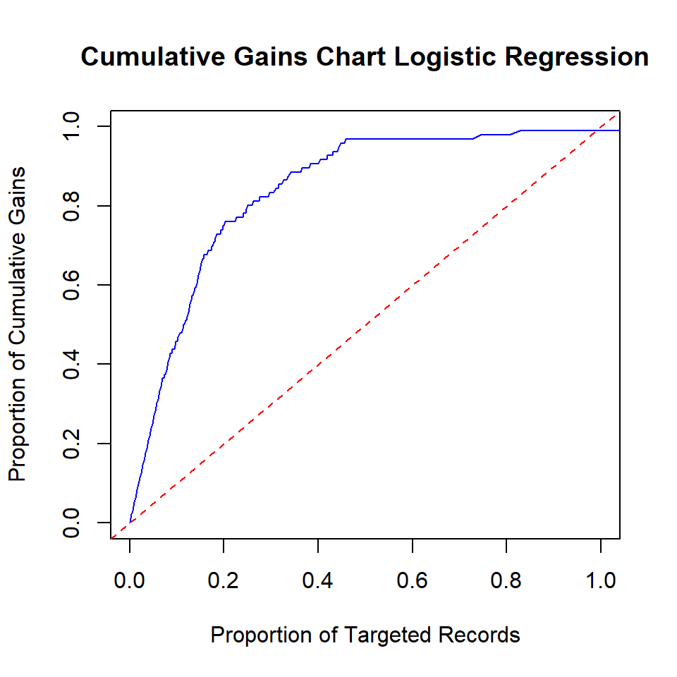

```r
test_cgc <- test %>%
  mutate(Personal.Loan = dplyr::recode(Personal.Loan, 'Yes' = 1, 'No' = 0))

cumu_chart(test_cgc$Personal.Loan, plr_predicted_proba$Yes, "Logistic Regression")
```

Z grafu lze vyčíst, že pokud vezmeme 20 procent případů, kterým model predikoval nejvyšší pravděpodobnost úspěchu, tak se v této množině nachází přibližně 75 procent všech pozitivních případů.

## Random Forest

```r
fitControl <- trainControl(
  method = "cv",
  number = 10,
  classProbs = T,
  savePredictions = T,
  search = 'random'
)
```

Funkce řídící proces učení. Agreguje v sobě:

- data, na kterých probíhá proces učení,
- použitou metodu ML (Random Forest),
- parametry procesu učení (10x cross validace, random search),
- kroky predzpracovnání dat (centrování, normalizace),
- počet prohledánání prostoru v rámci random search,
- evaluační metrika (Accuracy).

```r
set.seed(123)

rf_fit <- train(
  Personal.Loan ~ .,
  data = train,
  method = "rf",
  trControl = fitControl,
  preProc = c("center", "scale"),
  tuneLength = 6,
  metric = 'Accuracy'
)

rf_fit
```

```
## Random Forest
##
## 4000 samples
##   13 predictor
##    2 classes: 'No', 'Yes'
##
## Pre-processing: centered (13), scaled (13)
## Resampling: Cross-Validated (10 fold)
## Summary of sample sizes: 3600, 3600, 3601, 3601, 3599, 3600, ...
## Resampling results across tuning parameters:
##
##   mtry  Accuracy   Kappa
##    2    0.9787524  0.8636468
##    3    0.9874993  0.9240805
##    6    0.9885000  0.9307451
##   10    0.9882487  0.9293152
##   11    0.9882500  0.9296919
##
## Accuracy was used to select the optimal model using the largest value.
## The final value used for the model was mtry = 6.
```

Následuje vizualizace výsledků křížové validace na trénovacích datech. Graf zobrazuje hodnotu evaluační metriky pro jednotlivá nastavení hyperparametru *mtry* modelu metody RF v rámci křížové validace:

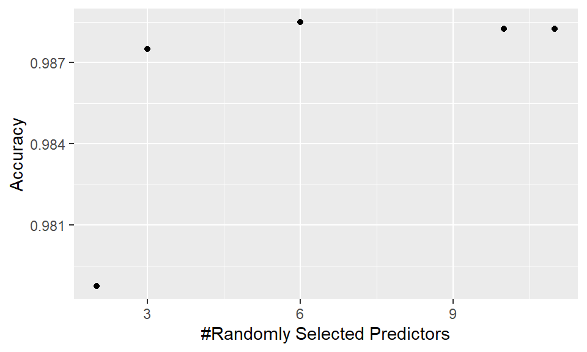

```r
ggplot(rf_fit)
```

Na základě, jak výpisu výsledků křížové validace, tak následné vizualizace, lze konstatoval, že model metody RF s *mtry = 6* dosahuje v rámci křízové validace na testovací části trénovacích dat nejlepších predikčních schopností. Hodnota evaluační metriky *Accuracy* dosahuje u modelu s tímto nastavením hyperparametru nejvyšší hodnoty. Tento model RF lze považovat za optimální v hyperparametech.

Nyní se v hyperparametrech optimální model RF použije pro predikci na testovacím datasetu.

```r
rf_predicted_class <- predict(rf_fit, newdata = test)
str(rf_predicted_class)
```

```
##  Factor w/ 2 levels "No","Yes": 1 1 1 1 1 1 1 1 1 1 ...
```

Natrénovaný model RF umožňuje predikovat pravděpodobnost příslušnosti testovacích záznamů k jednotlivým třídám cílového atributu:

```r
rf_predicted_proba <- predict(rf_fit, newdata = test, type = "prob")
head(rf_predicted_proba)
```

```
##    No Yes
## 6   1   0
## 8   1   0
## 18  1   0
## 26  1   0
## 27  1   0
## 32  1   0
```

Za účelem zhodnocení predikčních schopností modelu RF na testovacích datech si necháme zobrazit *matici záměn* včetně dopočítaných evaluačních metrik.

```r
confusionMatrix(data = rf_predicted_class, test$Personal.Loan)
```

```
## Confusion Matrix and Statistics
##
##           Reference
## Prediction  No Yes
##        No  902  13
##        Yes   2  83
##
##                Accuracy : 0.985
##                  95% CI : (0.9754, 0.9916)
##     No Information Rate : 0.904
##     P-Value [Acc > NIR] : < 2.2e-16
##
##                   Kappa : 0.9089
##
##  Mcnemar's Test P-Value : 0.009823
##
##             Sensitivity : 0.9978
##             Specificity : 0.8646
##          Pos Pred Value : 0.9858
##          Neg Pred Value : 0.9765
##              Prevalence : 0.9040
##          Detection Rate : 0.9020
##    Detection Prevalence : 0.9150
##       Balanced Accuracy : 0.9312
##
##        'Positive' Class : No
##
```

Ke zhodnocení predikčních schopností modelu RF jsou opět použity následující komplexnější metriky:

- ROC křivka.
- křivka kumulativních zisků.

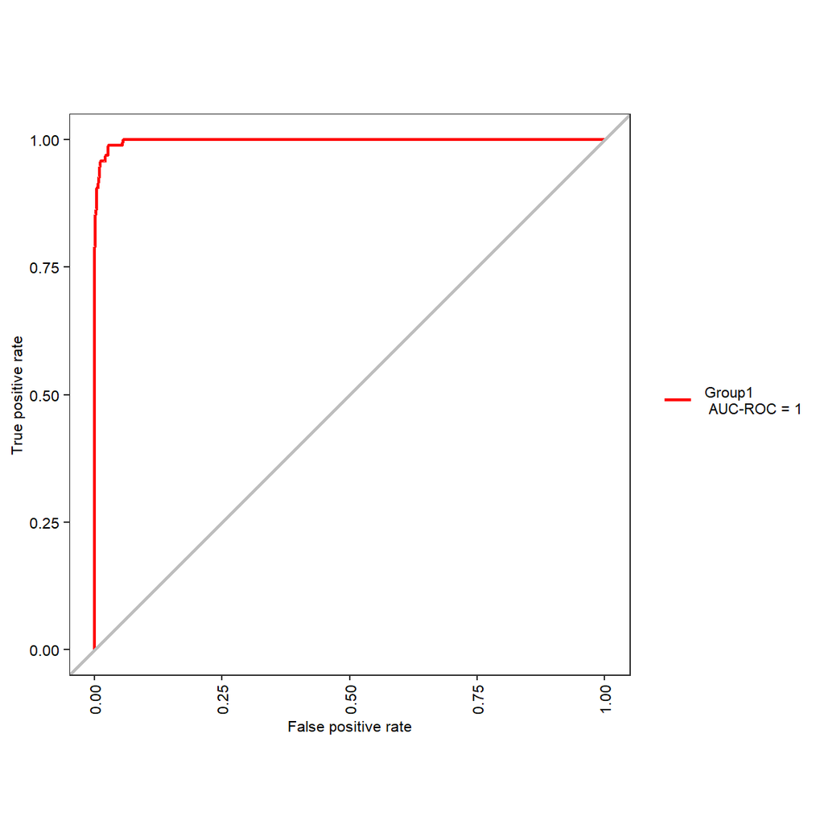

```r
rf_predicted_proba$obs <- test$Personal.Loan

roc_curve_rf <-
  evalm(
    rf_predicted_proba ,
    plots = 'r',
    rlinethick = 0.8,
    fsize = 8,
    bins = 8
  )
```

Ve srovnání s ROC křivkou u modelu LR je tato křivka blíže levému hornímu rohu, což značí, že model RF má lepší predikční schopnosti než model LR, a to z hlediska vztahu TP a FP poměru.

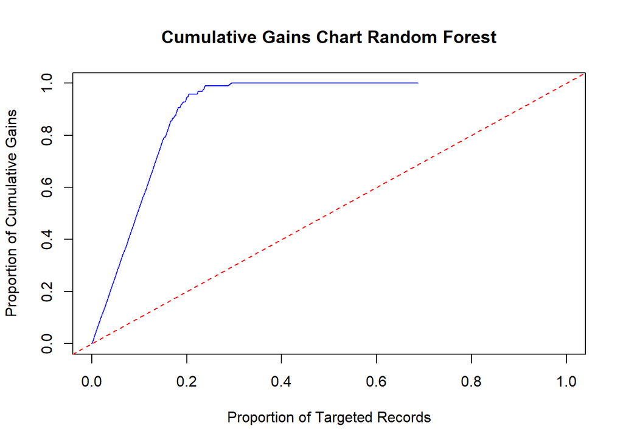

```r
cumu_chart(test_cgc$Personal.Loan, rf_predicted_proba$Yes, "Random Forest")
```

Z grafu lze vyčíst, že pokud vezmeme 20 procent případů, kterým model predikoval nejvyšší pravděpodobnost úspěchu, tak se v této množině nachází přibližně 95 procent všech pozitivních případů. To indikuje výrazně lepší predikční schopnosti modelu metody RF oproti LR.